# PLS 206: Introduction to Ordination

# Why ordination?

In previous lessons, we covered the use of principle component analysis (PCA) to reduce the dimensionality of numerous, collinear predictor (X) variables. However, the process of dimensionality reduction is not limited just to predictors – PCA and related techniques can be used to describe major axes of variation in a multivariate response (Y) variable.

*When do are we likely to have a multivariate response variable?* In ecology and other life sciences, species composition data is increasingly used as a response – think counts of plants occurring in different conservation areas or comparisons of gut microbiomes across different diets. The simplest approach to analyzing this sort of data would be to ask if the first species I found increases in response to some environmental factor, then repeat this univariate model for every species found. However, this approach would be tedious, miss out on key correlations between species, and suffer from multiple comparison problems.

Instead, we often want to evaluate how environmental factors control the abundance of multiple species *simultaneously*. The process of decomposing a species matrix, containing counts of different species (columns) by samples (rows) into a smaller number of gradients is known as **ordination**.

Ordination comes in two flavors:

- **Unconstrained Ordination**: Samples are arranged into a smaller number of dimensions, independent of any explanatory variables. Primarily used to visualize information and detect potential gradients. *Hypothesis generating.*
- **Constrained Ordination**: Samples are arranged onto a number of dimensions that are defined by a another set of environmental variables. Used to test relationships between species abundances and environmental gradients. *Hypothesis testing.*

In most applications, these two approaches work in tandem.  
________________________________________________________________________________

Regardless of the scale or taxa involved, most community (species x sample) data matrices share some general properties:

For any ordination method to be generally useful, it must be able to cope with the above properties of community data matrices.

[From Michael Palmer’s Ordination Site](http://ordination.okstate.edu/)

# The Species Matrix

To begin, we’ll pull an example species matrix from the `vegan` package in R. This data is from [Väre et al (1995)](https://onlinelibrary.wiley.com/doi/abs/10.2307/3236351), a study of reindeer grazing effects on understory plant communities.

The two components of this dataset are:

1. A species x sample matrix, “varespec”
2. A soil chemistry x sample matrix, “varechem”

```r
library(vegan); library(tidyverse); library(viridis)

data("varespec") # Community data
data("varechem") # Environmental data

veg_comm <- varespec
veg_envt <- varechem

head(veg_comm)
```

|  | Callvulg | Empenigr | Rhodtome | Vaccmyrt | Vaccviti | Pinusylv | Descflex | Betupube | Vacculig | Diphcomp | Dicrsp | Dicrfusc | Dicrpoly | Hylosple | Pleuschr | Polypili | Polyjuni | Polycomm | Pohlnuta | Ptilcili | Barbhatc | Cladarbu | Cladrang | Cladstel | Cladunci | Cladcocc | Cladcorn | Cladgrac | Cladfimb | … |
| --- | --- | --- | --- | --- | --- | --- | --- | --- | --- | --- | --- | --- | --- | --- | --- | --- | --- | --- | --- | --- | --- | --- | --- | --- | --- | --- | --- | --- | --- | --- |
| 18 | 0.55 | 11.13 | 0.00 | 0.00 | 17.80 | 0.07 | 0.00 | 0 | 1.60 | 2.07 | 0.00 | 1.62 | 0.00 | 0.0 | 4.67 | 0.02 | 0.13 | 0.00 | 0.13 | 0.12 | 0.00 | 21.73 | 21.47 | 3.50 | 0.30 | 0.18 | 0.23 | 0.25 | 0.25 | … |
| 15 | 0.67 | 0.17 | 0.00 | 0.35 | 12.13 | 0.12 | 0.00 | 0 | 0.00 | 0.00 | 0.33 | 10.92 | 0.02 | 0.0 | 37.75 | 0.02 | 0.23 | 0.00 | 0.03 | 0.02 | 0.00 | 12.05 | 8.13 | 0.18 | 2.65 | 0.13 | 0.18 | 0.23 | 0.25 | … |
| 24 | 0.10 | 1.55 | 0.00 | 0.00 | 13.47 | 0.25 | 0.00 | 0 | 0.00 | 0.00 | 23.43 | 0.00 | 1.68 | 0.0 | 32.92 | 0.00 | 0.23 | 0.00 | 0.32 | 0.03 | 0.00 | 3.58 | 5.52 | 0.07 | 8.93 | 0.00 | 0.20 | 0.48 | 0.00 | … |
| 27 | 0.00 | 15.13 | 2.42 | 5.92 | 15.97 | 0.00 | 3.70 | 0 | 1.12 | 0.00 | 0.00 | 3.63 | 0.00 | 6.7 | 58.07 | 0.00 | 0.00 | 0.13 | 0.02 | 0.08 | 0.08 | 1.42 | 7.63 | 2.55 | 0.15 | 0.00 | 0.38 | 0.12 | 0.10 | … |
| 23 | 0.00 | 12.68 | 0.00 | 0.00 | 23.73 | 0.03 | 0.00 | 0 | 0.00 | 0.00 | 0.00 | 3.42 | 0.02 | 0.0 | 19.42 | 0.02 | 2.12 | 0.00 | 0.17 | 1.80 | 0.02 | 9.08 | 9.22 | 0.05 | 0.73 | 0.08 | 1.42 | 0.50 | 0.17 | … |
| 19 | 0.00 | 8.92 | 0.00 | 2.42 | 10.28 | 0.12 | 0.02 | 0 | 0.00 | 0.00 | 0.00 | 0.32 | 0.02 | 0.0 | 21.03 | 0.02 | 1.58 | 0.18 | 0.07 | 0.27 | 0.02 | 7.23 | 4.95 | 22.08 | 0.25 | 0.10 | 0.25 | 0.18 | 0.10 | … |

```r
head(veg_envt)
```

|  | N | P | K | Ca | Mg | S | Al | Fe | Mn | Zn | Mo | Baresoil | Humdepth | pH |
| --- | --- | --- | --- | --- | --- | --- | --- | --- | --- | --- | --- | --- | --- | --- |
| 18 | 19.8 | 42.1 | 139.9 | 519.4 | 90.0 | 32.3 | 39.0 | 40.9 | 58.1 | 4.5 | 0.3 | 43.9 | 2.2 | 2.7 |
| 15 | 13.4 | 39.1 | 167.3 | 356.7 | 70.7 | 35.2 | 88.1 | 39.0 | 52.4 | 5.4 | 0.3 | 23.6 | 2.2 | 2.8 |
| 24 | 20.2 | 67.7 | 207.1 | 973.3 | 209.1 | 58.1 | 138.0 | 35.4 | 32.1 | 16.8 | 0.8 | 21.2 | 2.0 | 3.0 |
| 27 | 20.6 | 60.8 | 233.7 | 834.0 | 127.2 | 40.7 | 15.4 | 4.4 | 132.0 | 10.7 | 0.2 | 18.7 | 2.9 | 2.8 |
| 23 | 23.8 | 54.5 | 180.6 | 777.0 | 125.8 | 39.5 | 24.2 | 3.0 | 50.1 | 6.6 | 0.3 | 46.0 | 3.0 | 2.7 |
| 19 | 22.8 | 40.9 | 171.4 | 691.8 | 151.4 | 40.8 | 104.8 | 17.6 | 43.6 | 9.1 | 0.4 | 40.5 | 3.8 | 2.7 |

The `tabasco` function in vegan provides a simple heatmap of species (row) abundances vs. sample number (column). Yellow cells indicate high species abundances, white cells indicate the absence of a species in that sample.

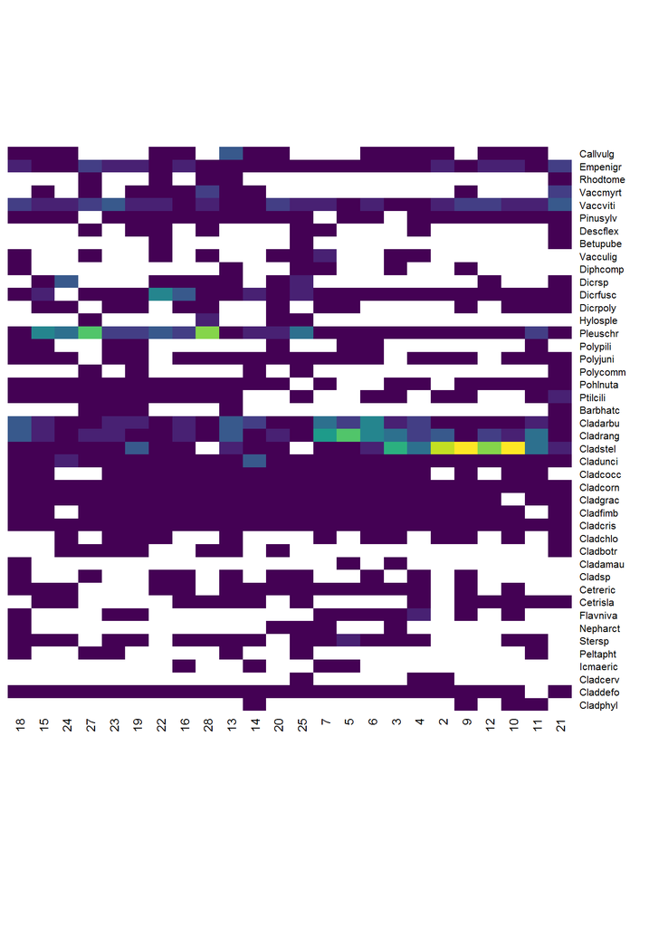

```r
vegan::tabasco(veg_comm, col = viridis(12, direction = -1))
```

What do you notice about species abundance / incidence in this plot? Is this dataset well-suited to ordination?

## Coenoclines

Relationships between species communities and environmental gradients are given their own name – *coenoclines*. The code below can be used to plot relationships between species abundance and different environmental variables. What do you notice about species distributions in response to different variables?

```r
coeno_plot <- function(chosen_var){

  var_to_plot <- veg_envt %>% select(chosen_var)

  cbind(veg_comm, var_to_plot) %>%
    gather(key = "species", value = "abundance", -chosen_var) %>%
    ggplot(aes(x = !! sym(chosen_var),
               y = abundance,
               color = species)) +
    geom_point() +
    stat_smooth(se = FALSE, alpha = .5, method = "loess") +
    ylim(-5, max(veg_comm))
}
```

```r
names(veg_envt)
```

```
##  [1] "N"        "P"        "K"        "Ca"       "Mg"       "S"
##  [7] "Al"       "Fe"       "Mn"       "Zn"       "Mo"       "Baresoil"
## [13] "Humdepth" "pH"
```

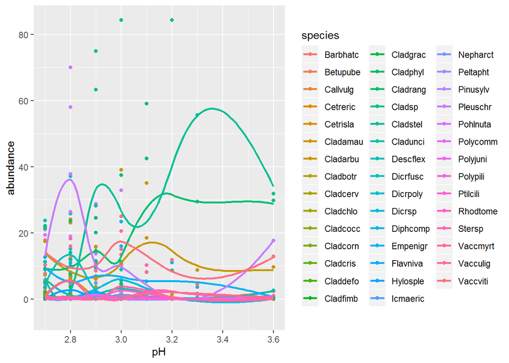

```r
coeno_plot("pH")
```

# Distance Measures

Across samples, it is clear that species abundances and instances vary considerably. Across all recorded species, how do we determine how different two samples are? Would we simply sum up the total differences between each column? Or some other approach?

These decisions underpin the importance of **distance measures** in ordination. Given a series of points across 1 - many dimensions, a distance measure provides a quantitative assessment of how *dissimilar* two samples are.

### How do we define dissimilarity?

Ecological similarity can be defined in a number of different ways, depending on the distance measure used. These metrics will be sensitive to different patterns in the data – in analyzing data, you will have to make a choice in how you express similarity.

Distance in lat-long space is referred to as **Euclidean distance**. Euclidean distance can also be generalized to many dimensions. The same is true for the block-by-block distance, appropriately named **Manhattan distance** or “taxicab distance”, which is the sum of differences in X + sum of differences in Y, etc.

Distance metrics have certain properties:

**A distance of zero means that samples are identical**
$$2. d(x, y) = 0 \iff x = y$$

**Distances are symmetric; It doesn’t matter where your starting point is**
$$3. d(x, y) = d(y, x)$$
**Triangle inequalty; a distance between two communities is less than or equal to the distance between those two communities and a third**
$$4. d(x, y) \leq d(x, z) + d(z, y)$$

**Note:** The last property is often violated by several popular ecological distance functions. In this case, these distances are considered “semimetric”. Bray-Curtis (Sorenson) dissimilarity is a popular metric that violates this property.

## What distance measure do I use?

The number of choices of different distance measures can be dizzying – thankfully, there are some common distance functions used in ecology that are defined by their relationship to species abundance and richness (presence/absence).

The central concerns to choosing a distance metric are:

1. How much weight do I want to give common vs. rare species?
2. What is the *length* of the environmental gradient that I am measuring? Are gradients long enough that species are expected to show unimodal patterns of abundance? Or do I expect linear relationships?
   - Difficulties in compressing multi-model relationships are often expressed as the “horseshoe effect” in the ordination. [Link to a good StackExchange discussion](https://stats.stackexchange.com/questions/158552/what-is-the-horseshoe-effect-and-or-the-arch-effect-in-pca-correspondence).
3. Am I willing to transform my data? [More on that here](https://link.springer.com/article/10.1007/s004420100716)

In addition to the standard Euclidean distance, two of the most popular dissimilarity measures in ecology are the Bray-Curtis (abundance-weighted) and Jaccard (binary, presence-absence) distances.

**Euclidean**
$$\sqrt{\sum_{i=1}^S (n_{1i} - n_{2i})^2}$$

- $n_{1i}$ = abundance of species $i$ in site 1
- $n_{2i}$ = abundance of species $i$ in site 2
- $S$ = total number of species
- *What is the total deviation in units of abundance between two communities*?

**Bray-Curtis:**
$$\sum_{i=1}^S \frac{2 * min(n_{1i}, n_{2i})}{\sum{n_{1i}} + \sum{n_2i}}$$

- $n_{1i}$ = abundance of species $i$ in site 1
- $n_{2i}$ = abundance of species $i$ in site 2
- $S$ = total number of species
- *What proportion of total species abundances differ between two communities*?

**Jaccard:**
$$\frac{A}{A + B+ C}$$

- $A:$ number of species in both sites
- $B:$ number of species in first site only
- $C:$ number of species in second site only
- *What proportion of the combined species pool is found between two communities*?

```r
# 2 Example ecological communities
com1 <- data.frame(spA = 25, spB = 50, spC = 10, spD = 0, spE = 0, spF = 0, spG = 0, spH = 0, row.names = "Com 1")
com2 <- data.frame(spA = 12, spB = 25, spC = 5, spD = 1, spE = 2, spF = 1, spG = 1, spH = 1, row.names = "Com 2")
(com_sample <- rbind(com1, com2))
```

|  | spA | spB | spC | spD | spE | spF | spG | spH |
| --- | --- | --- | --- | --- | --- | --- | --- | --- |
| Com 1 | 25 | 50 | 10 | 0 | 0 | 0 | 0 | 0 |
| Com 2 | 12 | 25 | 5 | 1 | 2 | 1 | 1 | 1 |

```r
# Euclidean distance #
# Large differences due to relative abundances -- agnostic to species identity
vegdist(com_sample, method = "euclidean")
```

```
##          Com 1
## Com 2 28.75761
```

```r
# Bray-Curtis distance #
# Difference in abundance relative to total abundance of that species, bounded between 0 and 1
vegdist(com_sample, method = "bray")
```

```
##           Com 1
## Com 2 0.3684211
```

```r
# Jaccard (binary) distance #
# 3/8 species shared, bounded between 0 and 1
vegdist(com_sample, method = "jaccard", binary = TRUE)
```

```
##       Com 1
## Com 2 0.625
```

# Unconstrained Ordination

## Visualizing Dissimilarity Matrices

Similarly to a PCA, distance matrices can be expressed in a smaller number of dimensions through the process of **ordination**. In fact, PCA is a form of ordination that preserves *Euclidean* distances between points. However, if we want to capture similarity between samples using other distance measures, we need to use an alternative method of ordination, such as PCoA (Principal *Coordinates* Analysis) or NMDS (Non-Metric Multidimensional Scaling). Here, we’ll discuss use of the latter.

## NMDS

NMDS is an increasingly popular **unconstrained ordination** method to express the non-euclidean relationships between multiple samples. Unlike a PCA, NMDS does not have a closed-form solution, instead relying on computer optimization to express a matrix in a given number of dimensions.

**Advantages**

- No eigenvalues! The distance between in reduced space does not depend on the axis. Distance between points in Y = Distance between points in X
- Different distance measures can be expressed.
- Often easier to interpret

**Disadvantages**

- Results from computer optimization. Can converge on different solutions, so plots look different between runs.
- Can poorly represent multivariate relationships. Must evaluate model fit using stress and adjust accordingly.

Let’s return to the vegetation patch data, `varespec`. To generate a matrix of distances between points, we can use the `vegdist` function from the `vegan` library. The resulting matrix contains every single pairwise comparison in the data, producing an $n*n$ square matrix with $n\choose{2}$ unique values.

```r
# Bray-curtis dissimilarity between samples
distmat <- vegan::vegdist(veg_comm, method = "bray")

# First 5 rows/columns
as.matrix(distmat)[1:5, 1:5]
```

```
##           18        15        24        27        23
## 18 0.0000000 0.5310021 0.6680661 0.5621247 0.3747078
## 15 0.5310021 0.0000000 0.3597783 0.4055610 0.3652097
## 24 0.6680661 0.3597783 0.0000000 0.4934947 0.5020306
## 27 0.5621247 0.4055610 0.4934947 0.0000000 0.4286111
## 23 0.3747078 0.3652097 0.5020306 0.4286111 0.0000000
```

Row names are given here as both column and row names, showing which communities are compared.

Note that this matrix is *symmetric* – elements in the upper diagonal and lower diagonal are the same, as distance functions are identical no matter the sample order. Elements of the diagonal are all zero, as a community is identical to itself.

To help illustrate the NMDS, we can assign some grouping variable to color the datapopints by. Below, I make a simple group of values above / below the median pH value in the associated environmental dataset.

```r
colors <- c("red", "blue")
ph_group <- as.factor(if_else(veg_envt$pH < median(veg_envt$pH), "pH < 2.9",  "pH > 2.9"))
```

NMDS is performed in `vegan` using the `metaMDS` function. Notice that the orientation of points depends strongly on the distance metric we use:

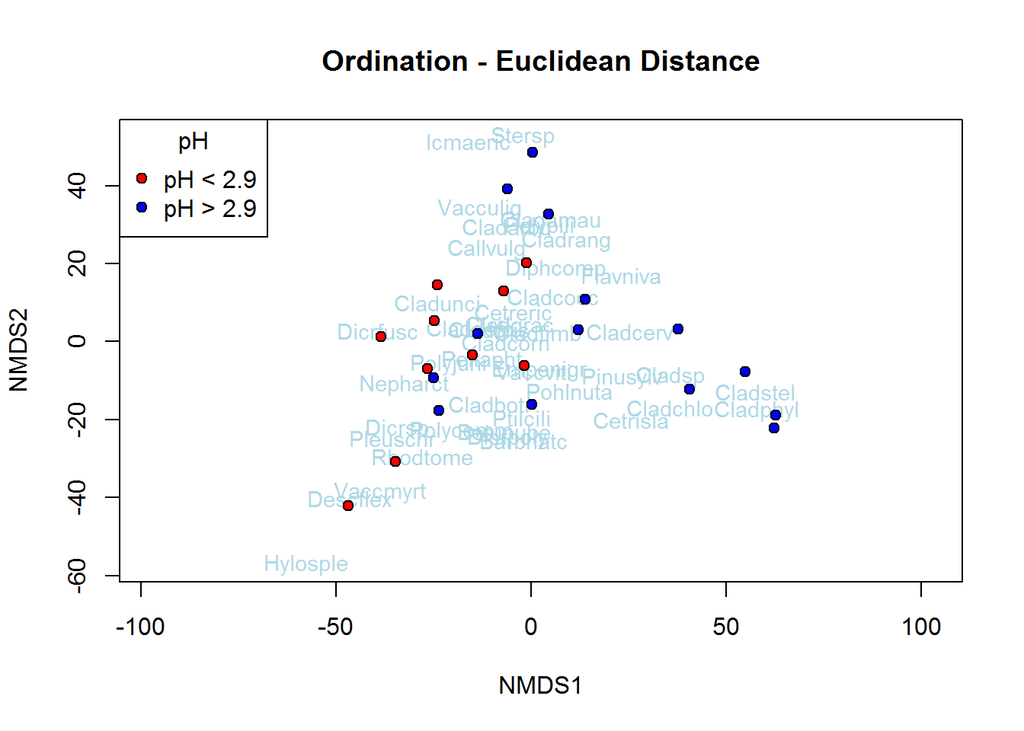

```r
plot_nmds <- function(my_nmds, title){
  fig <- ordiplot(my_nmds, type = "none", main = title)
  text(fig, "species", col="lightblue", cex=0.9)
  points(fig, "sites", pch=21, bg = colors[as.numeric(ph_group)])
  with(veg_envt, legend("topleft", levels(ph_group), pch = 21,  pt.bg = colors,
  title = "pH"))
}

nmds.eucl <- metaMDS(veg_comm, distance = "euclidean", binary = FALSE, autotransform = FALSE, trace = FALSE)
plot_nmds(nmds.eucl, "Ordination - Euclidean Distance")
```

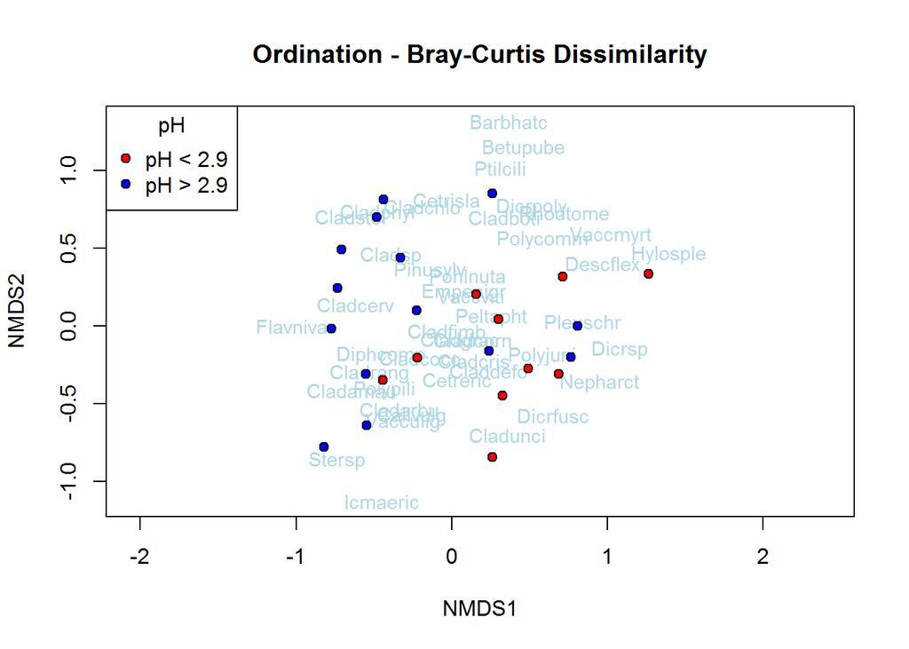

```r
nmds.bray <- metaMDS(veg_comm, distance = "bray", binary = FALSE, autotransform = FALSE, trace = FALSE)
plot_nmds(nmds.bray, "Ordination - Bray-Curtis Dissimilarity")
```

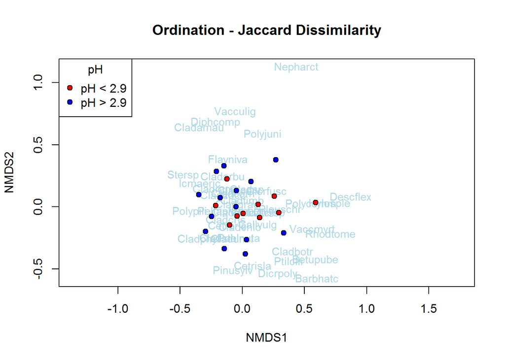

```r
nmds.jacc <- metaMDS(veg_comm, distance = "jaccard", binary = TRUE, autotransform = FALSE, trace = FALSE)
plot_nmds(nmds.jacc, "Ordination - Jaccard Dissimilarity")
```

- Are there different patterns, depending on what distance metric is used?
- What might patterns that depend on metric tell us about the process we observe?

## NMDS Stress

How well does this two-dimensional representation of points reflect our observed dissimilarities? From our distance matrix object, we know how similar two points are from one another.

The **stress** value of an NMDS provides an evaluation of the accuracy of this two-dimensional representation. Stress is a measure based on rank-order discrepancies in distance – whether a point has a neighbor that is closer in low-dimensional distance than another neighbor which is *known* to be more similar. High stress values indicate that the low-dimensional representation of points has a number of cases where this poor configuration is present.

The `stressplot` object shows a visualization of this stress, where observed community distances on the X-axis are compared to ordination (xy-coordinate) distances on the Y-axis. Note that the non-linear fit smoothing line has a higher $R^2$ than the linear one – rank-order differences in points are emphasized in NMDS.

```r
# Stress value
nmds.bray$stress
```

```
## [1] 0.1000211
```

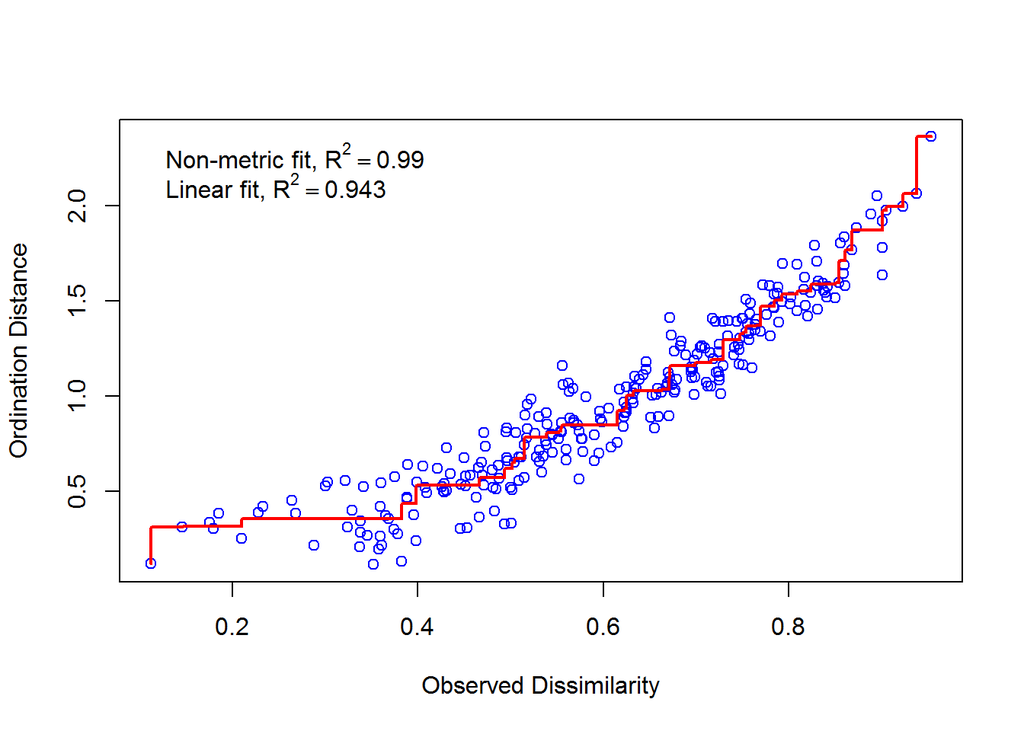

```r
# Visualization of stress
stressplot(nmds.bray)
```

## The NMDS object

If you want to create your plots, the observations and species loadings can be extracted from the NMDS object. Like a PCA, correlations between points and species indicate how well changes in the abundance/occurrence of different species drive differences between samples.

```r
# NMDS points -- X and Y coordinates of the observed community samples
head(nmds.bray$points)
```

```
##          MDS1         MDS2
## 18 -0.2198966 -0.204528786
## 15  0.4909435 -0.274525898
## 24  0.8073233  0.001055728
## 27  0.7138559  0.316769033
## 23  0.3001174  0.042186877
## 19  0.1571968  0.203738394
```

```r
# NMDS species -- the relationships between species loadings and the ordination figure
head(nmds.bray$species)
```

```
##                 MDS1       MDS2
## Callvulg -0.25359827 -0.5770471
## Empenigr  0.07920012  0.2174699
## Rhodtome  0.71931141  0.7284369
## Vaccmyrt  1.01986135  0.5801927
## Vaccviti  0.12354425  0.1944954
## Pinusylv -0.14397899  0.3547141
```

## Adding environmental variables

In some ecological applications, we may only have data on species assemblages and no environmental context. If we’re interested in seeing whether communities are assembling across linear gradients, **indirect gradient analysis** may be used to capture these patterns.

However, in many cases, samples are accompanied by measurements of 1 or more variables that capture environmental gradients. To visualize how these environmental variables correlate with ordination, `envfit` will construct permutation-based vectors. Strong correlations have longer arrows, while weaker correlations have smaller ones.

A significance test can be used to determine how ordination structure explains variation in a given environmental factor, though note that this does not provide a strong test of whether these variables drive community dissimilarity observed.

```r
# Environmental Vectors -- projecting environmental variables on an existing NMDS object
env_vec <- envfit(nmds.bray, veg_envt)
env_vec
```

```
##
## ***VECTORS
##
##             NMDS1    NMDS2     r2 Pr(>r)
## N         0.01870 -0.99983 0.1885  0.133
## P         0.66077  0.75059 0.2898  0.033 *
## K         0.85358  0.52096 0.1830  0.121
## Ca        0.83356  0.55243 0.3534  0.012 *
## Mg        0.84814  0.52977 0.2901  0.029 *
## S         0.41304  0.91071 0.0884  0.379
## Al       -0.98935  0.14556 0.4888  0.004 **
## Fe       -0.99350  0.11384 0.4081  0.008 **
## Mn        0.99233  0.12358 0.4293  0.006 **
## Zn        0.92740  0.37407 0.1650  0.128
## Mo       -0.85989 -0.51048 0.0476  0.584
## Baresoil  0.91936 -0.39341 0.1877  0.117
## Humdepth  0.98855  0.15087 0.4415  0.003 **
## pH       -0.86063  0.50923 0.2252  0.072 .
## ---
## Signif. codes:  0 '***' 0.001 '**' 0.01 '*' 0.05 '.' 0.1 ' ' 1
## Permutation: free
## Number of permutations: 999
```

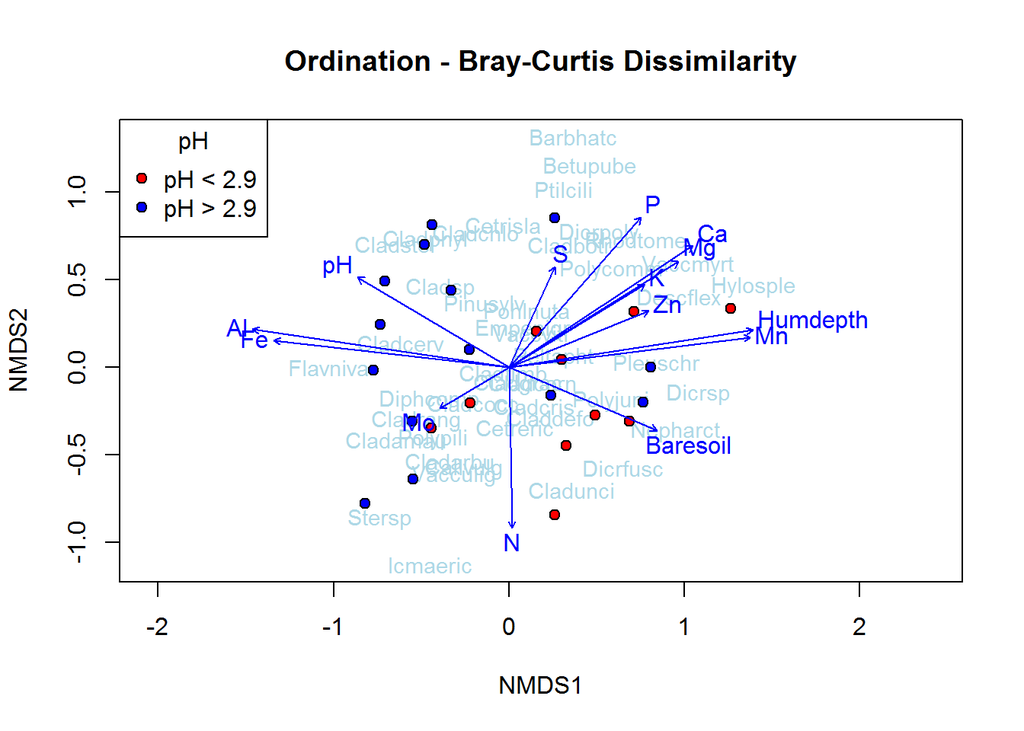

```r
# Adding to previous plot
plot_nmds(nmds.bray, "Ordination - Bray-Curtis Dissimilarity")
plot(env_vec)
```

# Constrained Ordination

The counterpart to linear regression in ordination is known as *constrained* ordination. Rather than trying to visualize relationships between species and samples, constrained ordination attempts to explain the maximum variation in species composition.

Constrained ordination combines both multiple linear regression and PCA to estimate how environmental variables can be combined to produce environmental gradients that capture changes in species abundance.

Constrained ordination produces both a matrix of explained variation that can be visualized through a PCA, as well as a matrix of unexplained variation that may be visualized as a separate PCA.

### Types of Constrained Ordination

- RDA - Redundancy Analysis; Community dissimilarity based on Euclidean distance.
- CCA - Canonical Correspondence Analysis; Community dissimilarity based on Chi-square distance
- db-RDA - distance-based Redundancy Analysis: Community dissimilarity based on a chosen distance metric

## Fitting the RDA object

`vegan` will fit all three versions of ordination using `rda` (RDA), `cca` (CCA), and `capscale` or `dbrda` (db-RDA). Due to similarities in their underlying methods, all objects created by these functions share similar nomenclature, despite terms varying in other sources.

### Calling `rda`

RDA can be called like any linear model. In this case, we’re estimating our community, `veg_comm` as a function of all our environmental variables `~ ., data = veg_envt`

The summary object of an RDA is quite large, but contains a wealth of useful information. Key points to notice are:

- Variance (Inertia) partitioning: how much of the observed community disimilarity can we explain using our environmental variables?
- Importance of components: How are axes in constrained variation (RDA) and unconstrained variation (PC) composed? Like a PCA, large eigenvalues describe important axes of variation.
- Site and species scores: Similar to interpretation of a PCA.

```r
veg_rda <- vegan::rda(veg_comm ~ ., data = veg_envt)
summary(veg_rda)
```

```
##
## Call:
## rda(formula = veg_comm ~ N + P + K + Ca + Mg + S + Al + Fe +      Mn + Zn + Mo + Baresoil + Humdepth + pH, data = veg_envt)
##
## Partitioning of variance:
##               Inertia Proportion
## Total          1825.7     1.0000
## Constrained    1459.9     0.7997
## Unconstrained   365.8     0.2003
##
## Eigenvalues, and their contribution to the variance
##
## Importance of components:
##                           RDA1     RDA2      RDA3     RDA4    RDA5     RDA6
## Eigenvalue            820.1042 399.2847 102.56168 47.63169 26.8382 24.04809
## Proportion Explained    0.4492   0.2187   0.05618  0.02609  0.0147  0.01317
## Cumulative Proportion   0.4492   0.6679   0.72409  0.75019  0.7649  0.77806
##                           RDA7      RDA8     RDA9    RDA10    RDA11    RDA12
## Eigenvalue            19.06438 10.166995 4.428786 2.272036 1.535326 0.925528
## Proportion Explained   0.01044  0.005569 0.002426 0.001245 0.000841 0.000507
## Cumulative Proportion  0.78850  0.794069 0.796495 0.797740 0.798581 0.799088
##                           RDA13     RDA14      PC1      PC2      PC3      PC4
## Eigenvalue            0.7155102 0.3118612 186.1917 88.46419 38.18828 18.40207
## Proportion Explained  0.0003919 0.0001708   0.1020  0.04846  0.02092  0.01008
## Cumulative Proportion 0.7994795 0.7996503   0.9016  0.95009  0.97101  0.98109
##                             PC5      PC6      PC7      PC8       PC9
## Eigenvalue            12.839433 10.55197 5.519405 4.521057 1.0922062
## Proportion Explained   0.007033  0.00578 0.003023 0.002476 0.0005983
## Cumulative Proportion  0.988122  0.99390 0.996925 0.999402 1.0000000
##
## Accumulated constrained eigenvalues
## Importance of components:
##                           RDA1     RDA2      RDA3     RDA4     RDA5     RDA6
## Eigenvalue            820.1042 399.2847 102.56168 47.63169 26.83822 24.04809
## Proportion Explained    0.5618   0.2735   0.07025  0.03263  0.01838  0.01647
## Cumulative Proportion   0.5618   0.8353   0.90551  0.93814  0.95653  0.97300
##                           RDA7      RDA8     RDA9    RDA10    RDA11    RDA12
## Eigenvalue            19.06438 10.166995 4.428786 2.272036 1.535326 0.925528
## Proportion Explained   0.01306  0.006964 0.003034 0.001556 0.001052 0.000634
## Cumulative Proportion  0.98606  0.993021 0.996054 0.997611 0.998662 0.999296
```

[output cut: 120 more lines]

```
##              RDA1     RDA2     RDA3      RDA4      RDA5      RDA6
## N        -0.37451  0.40005 -0.32028  0.120999 -0.021093  0.248110
## P        -0.07887 -0.67736 -0.18434 -0.212893 -0.346547 -0.006476
## K        -0.20146 -0.54606 -0.07107  0.248513 -0.530396 -0.100114
## Ca       -0.23542 -0.59524  0.04435 -0.126410 -0.106923  0.179456
## Mg       -0.25801 -0.50325  0.05625 -0.250266 -0.347164 -0.037531
## S         0.11042 -0.46983  0.07747  0.053454 -0.725932 -0.094191
## Al        0.62279  0.32064 -0.21908  0.055570 -0.538971 -0.219545
## Fe        0.53855  0.36246 -0.36254 -0.005091 -0.204949 -0.176280
## Mn       -0.53181 -0.55604 -0.10457  0.116995  0.076883 -0.063081
## Zn       -0.18926 -0.46093 -0.08390 -0.214118 -0.557270  0.368514
## Mo        0.08255  0.15128  0.12569 -0.054562 -0.716923 -0.163114
## Baresoil -0.58452  0.02519  0.70509 -0.179725 -0.121501 -0.067668
## Humdepth -0.52825 -0.49892  0.39395  0.105904 -0.005877 -0.228625
## pH        0.48529  0.20916 -0.40764 -0.282358  0.098835  0.168733
```

### Variance Decomposition of RDA

```r
anova(veg_rda)
```

|  | Df | Variance | F | Pr(>F) |
| --- | --- | --- | --- | --- |
| Model | 14 | 1459.8891 | 2.565818 | 0.005 |
| Residual | 9 | 365.7704 | NA | NA |

$R^2$ = 1459.89 / (1459.89 + 365.77) = 0.80

### Constrained RDA Axes

Like a PCA, the eigenvalues of RDA axes represent the fraction of variance that is explained by a given axis. In this case, we see the presence of two large RDA axes, indicating the presence of two strong environmental gradients that were observed to correlate with species abundance.

```r
veg_rda$CCA$eig
```

```
##        RDA1        RDA2        RDA3        RDA4        RDA5        RDA6
## 820.1042107 399.2847431 102.5616781  47.6316940  26.8382218  24.0480875
##        RDA7        RDA8        RDA9       RDA10       RDA11       RDA12
##  19.0643756  10.1669954   4.4287860   2.2720357   1.5353257   0.9255277
##       RDA13       RDA14
##   0.7155102   0.3118612
```

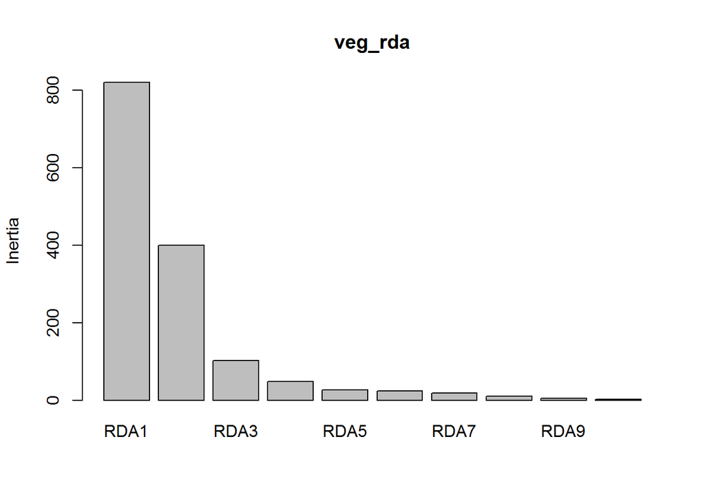

```r
screeplot(veg_rda)
```

### Unconstrained PCA Axes (Residuals)

Eigenvalues of the unconstrained variation can also be interesting – large variance across single dimensions reflect strong gradients in the residuals. These can reflect unobserved ecological processes that we may have missed in our sampling.

```r
veg_rda$CA$eig
```

```
##        PC1        PC2        PC3        PC4        PC5        PC6        PC7
## 186.191732  88.464194  38.188277  18.402075  12.839433  10.551972   5.519405
##        PC8        PC9
##   4.521057   1.092206
```

### Fitted values

Fitted (estimated) species abundances across sites can be called using predict()

```r
head(predict(veg_rda)[,1:5])
```

```
##      Callvulg  Empenigr    Rhodtome   Vaccmyrt Vaccviti
## 18 -0.3011956 12.199953  0.18612486 -2.0077465 19.42163
## 15  2.2815377  9.223692  0.95719513  3.8279863 14.83554
## 24  0.2814485  1.352557 -0.03336222 -0.5692336 13.85235
## 27  0.6930281  8.832771  1.26117287  5.4449661 12.56049
## 23 -1.4321608 11.285113 -0.08854819  3.3501278 18.45637
## 19  0.3111303 11.680112  1.10541064  5.2830738 15.50446
```

### Visualizing the ordination

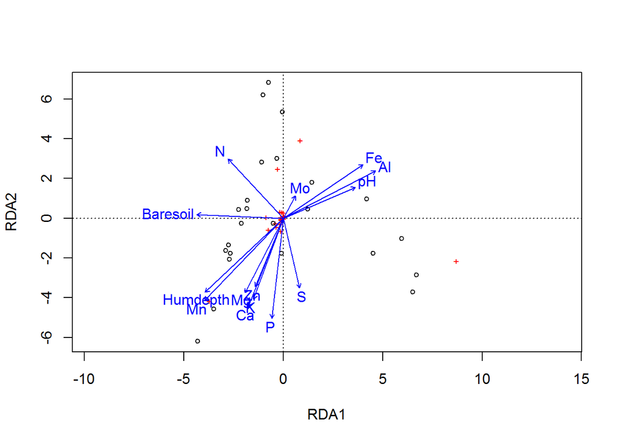

```r
ordiplot(veg_rda)
```

```r
vif.cca(veg_rda)
```

```
##         N         P         K        Ca        Mg         S        Al        Fe
##  1.884049  6.184742 11.746873  9.825650  9.595203 18.460717 20.331905  8.849137
##        Mn        Zn        Mo  Baresoil  Humdepth        pH
##  5.168278  7.755110  4.575108  2.213443  5.638807  6.910118
```

```r
step_mod <- ordistep(veg_rda, trace = FALSE)
```

```r
summary(step_mod)
```

```
##
## Call:
## rda(formula = veg_comm ~ K + Mg + S + Mn + Mo + Baresoil + Humdepth,      data = veg_envt)
##
## Partitioning of variance:
##               Inertia Proportion
## Total          1825.7     1.0000
## Constrained    1171.9     0.6419
## Unconstrained   653.7     0.3581
##
## Eigenvalues, and their contribution to the variance
##
## Importance of components:
##                          RDA1     RDA2     RDA3     RDA4    RDA5     RDA6
## Eigenvalue            733.992 291.7609 81.51255 31.59935 23.3638 7.437833
## Proportion Explained    0.402   0.1598  0.04465  0.01731  0.0128 0.004074
## Cumulative Proportion   0.402   0.5619  0.60650  0.62381  0.6366 0.640682
##                           RDA7      PC1       PC2      PC3      PC4      PC5
## Eigenvalue            2.266031 303.0746 161.46730 74.90196 33.36377 24.63528
## Proportion Explained  0.001241   0.1660   0.08844  0.04103  0.01827  0.01349
## Cumulative Proportion 0.641923   0.8079   0.89637  0.93740  0.95568  0.96917
##                             PC6       PC7      PC8      PC9     PC10     PC11
## Eigenvalue            15.132006 12.696570 9.515557 8.680481 5.306987 2.110286
## Proportion Explained   0.008289  0.006955 0.005212 0.004755 0.002907 0.001156
## Cumulative Proportion  0.977459  0.984414 0.989626 0.994381 0.997287 0.998443
##                            PC12      PC13      PC14      PC15      PC16
## Eigenvalue            1.5419177 0.7591346 0.3018121 1.421e-01 9.693e-02
## Proportion Explained  0.0008446 0.0004158 0.0001653 7.784e-05 5.309e-05
## Cumulative Proportion 0.9992879 0.9997037 0.9998691 9.999e-01 1.000e+00
##
## Accumulated constrained eigenvalues
## Importance of components:
##                           RDA1     RDA2     RDA3     RDA4     RDA5     RDA6
## Eigenvalue            733.9921 291.7609 81.51255 31.59935 23.36380 7.437833
## Proportion Explained    0.6263   0.2490  0.06955  0.02696  0.01994 0.006347
## Cumulative Proportion   0.6263   0.8753  0.94482  0.97178  0.99172 0.998066
##                           RDA7
## Eigenvalue            2.266031
## Proportion Explained  0.001934
## Cumulative Proportion 1.000000
```

[output cut: 109 more lines]

```
## 10  5.9450 -3.3326  0.0029128 -1.63542 -2.1621  5.8286
## 11 -0.2432  1.2236  5.1356932 -1.39394 -0.4041  6.6277
## 21 -3.0847  4.5535 -4.3786335  0.63618 -2.9809  1.8099
##
##
## Biplot scores for constraining variables
##
##              RDA1    RDA2      RDA3      RDA4     RDA5     RDA6
## K        -0.24240 -0.6233  0.004402  0.178950  0.49834  0.51606
## Mg       -0.30223 -0.5442 -0.151935 -0.469559  0.35372  0.29902
## S         0.08916 -0.5636 -0.195570 -0.071481  0.72550  0.30636
## Mn       -0.59176 -0.5863  0.086486  0.004269 -0.07761  0.04694
## Mo        0.09571  0.1689 -0.145076 -0.008860  0.85300 -0.45246
## Baresoil -0.62100  0.1381 -0.752140  0.063553  0.02879  0.15289
## Humdepth -0.58902 -0.4986 -0.461879  0.175559 -0.02600 -0.37392
```

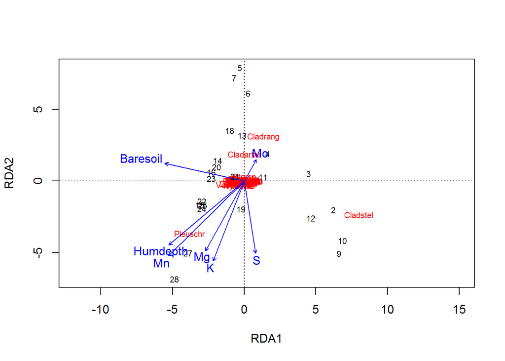

```r
plot(step_mod)
```

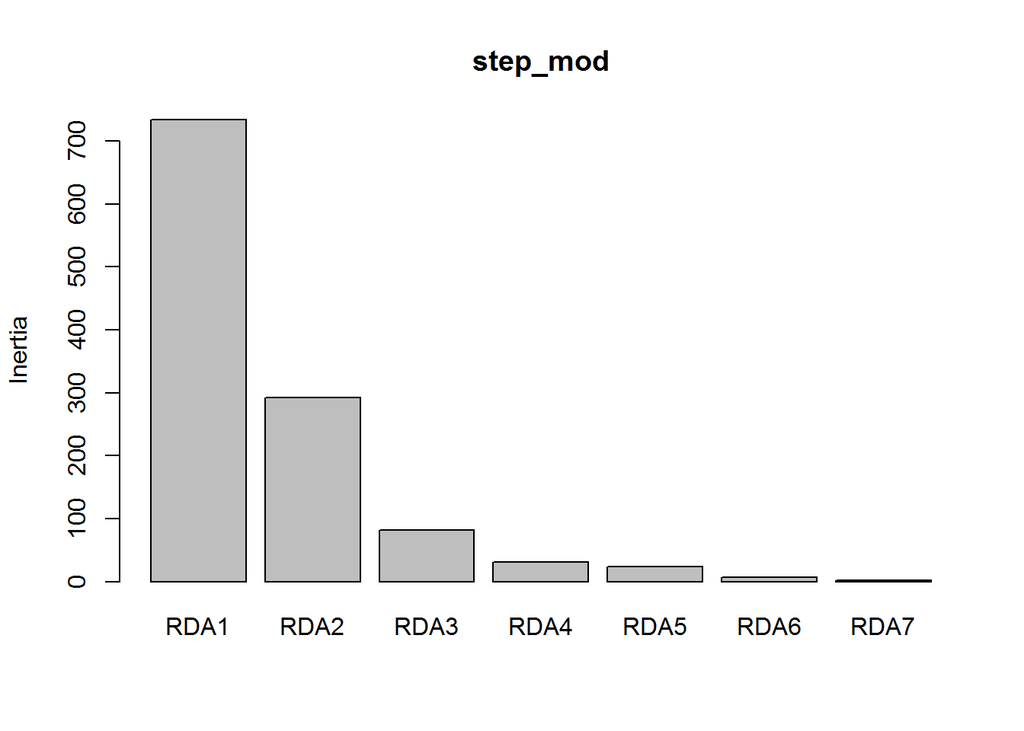

```r
screeplot(step_mod)
```

```r
var_comp <- data.frame(inertcomp(veg_rda))
var_comp$frac <- var_comp$CCA / (var_comp$CCA + var_comp$CA)
var_comp$MeanCover <- colMeans(veg_comm)
var_comp <- var_comp[order(var_comp$MeanCover, decreasing = TRUE),]
var_comp
```

|  | CCA | CA | frac | MeanCover |
| --- | --- | --- | --- | --- |
| Cladstel | 7.215844e+02 | 1.378926e+02 | 0.8395622 | 20.279583333 |
| Cladrang | 1.875570e+02 | 3.476091e+01 | 0.8436433 | 16.196250000 |
| Pleuschr | 3.123968e+02 | 4.455506e+01 | 0.8751791 | 15.748750000 |
| Vaccviti | 2.706177e+01 | 1.175655e+01 | 0.6971392 | 11.459583333 |
| Cladarbu | 7.328472e+01 | 3.913993e+01 | 0.6518563 | 10.627083333 |
| Empenigr | 1.217939e+01 | 1.059943e+01 | 0.5346805 | 6.332916667 |
| Dicrfusc | 4.362034e+01 | 3.927876e+01 | 0.5261859 | 4.730000000 |
| Cladunci | 8.083968e+00 | 1.659875e+01 | 0.3275153 | 2.345000000 |
| Vaccmyrt | 1.417196e+01 | 9.046066e+00 | 0.6103860 | 2.112916667 |
| Callvulg | 2.314414e+01 | 1.733804e+00 | 0.9303076 | 1.877916667 |

[output cut: 34 more lines]